# Portfolio assignment 10

Perform a bivariate analysis (Pearson correlation and scatter plot) on at least 1 combination of 2 columns with numeric data in the dataset that you chose in portfolio assignment 4. Does the correlation and scatter plot match your expectations? Add your answer to your notebook.

```python
import pandas as pd
pd.options.mode.chained_assignment = None
```

```python
data = pd.read_csv('4.data.txt')
data.shape
```

```
(467, 34)
```

### Pov & Urate: clean data and convert to float

```python
data = data[data.pov != '-']
data['pov'] = data['pov'].astype(float)
data['urate'] = data['urate'] * 100
```

```python
data['urate'] = data['urate'].astype(float)
```

### Correlation

```python
datacorr = data[['urate', 'pov']].corr()
datacorr.style.background_gradient(cmap='coolwarm', axis=None).format(precision=2)
```

|  | urate | pov |
| --- | --- | --- |
| urate | 1.00 | 0.59 |
| pov | 0.59 | 1.00 |

I chose the fields unemploymentrate (urate) and povertyrate (pov). Both values are on tract-level.

- The povertyrate represents the percentage of people who live below the povertyline, which is a minimum income of \$1.90 per day
- The unemploymentrate represents the percentage of people who are unemployed

I expected there to be a correlation, for people who are unemployed are more likely to live below the povertyline, while employed people are usually richer, or at least can keep themselves and there families above the povertyline.

The 0.59 correlation is not very strong, but there a weak correlation between those two values.

### Scatterplot

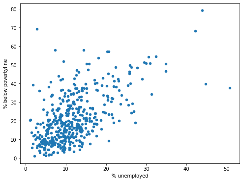

```python
data.plot(kind='scatter', x='urate', y='pov', figsize=(8, 6), xlabel='% unemployed', ylabel='% below povertyline')
```

In this scatterplot there is cloud in the bottom-left corner, stretching out to the centre. The multitude of dots in the bottom-left means there is less poverty in tracts where there is less unemployment.

We can also see there are a lot of people who live below the poverty line, the most dots appear between the 5% and 30%. If in a tract 15% of the people are poor, that's quite a lot. You wouldn't expect these numbers in a first world country.